{% raw %}

{% endraw %} {% raw %}

```python
from node2vec import node2vec
```

{% endraw %}

# Load the Dataset

The test of whether node2vec can incorporate directional information resides in the directed stochastic block model. With the right parameter values (a uniform $\alpha_{ij}$), it's impossible to distinguish the clusters *without* employing directional information.

node2vec does appear to work on directed adjacency matrices, but the embeddings produced by node2vec suffer from the trevails of enforced symmetry. The embedding of $i$ has the same relation to $j$, as $j$ to $i$. Does this hinder node2vec from learning a reasonable embedding of directed data?

We'll start by loading the directed SBM:

{% raw %}

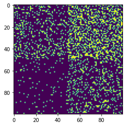

```python
from directed_graphs.datasets import DirectedStochasticBlockModel
aij = np.array([[0.4,0.4],[0.4,0.4]])
bij = np.array([[0.5,0.9],[0.1,0.5]])
dataset = DirectedStochasticBlockModel(num_nodes=100, num_clusters=2, aij = aij, bij = bij)
data = dataset[0] # there is only graph in this dataset
sparse_A = torch.sparse_coo_tensor(data.edge_index,torch.ones(data.edge_index.shape[1]))
A = sparse_A.to_dense()
plt.imshow(A)
```

{% endraw %}

The dataset must be converted to networkx format for node2vec.

{% raw %}

```python
import networkx as nx
from torch_geometric.utils import to_networkx
G_nx = to_networkx(data, to_undirected=False)
```

{% endraw %} {% raw %}

```python
import node2vec
```

{% endraw %} {% raw %}

```python
from node2vec import Node2Vec
```

{% endraw %} {% raw %}

```python
node2vec = Node2Vec(G_nx, dimensions=64, walk_length=30, num_walks=200, workers=4)  # Use temp_folder for big graphs
# Embed nodes
model = node2vec.fit(window=10, min_count=1, batch_words=4)  # Any keywords acceptable by gensim.Word2Vec can be passed, `dimensions` and `workers` are automatically passed (from the Node2Vec constructor)

# Look for most similar nodes
model.wv.most_similar('2')  # Output node names are always strings
```

```
[('16', 0.45608943700790405),
 ('37', 0.39687207341194153),
 ('10', 0.3902360200881958),
 ('31', 0.34752026200294495),
 ('82', 0.33593955636024475),
 ('19', 0.31738972663879395),
 ('25', 0.31701967120170593),
 ('69', 0.3156047761440277),
 ('50', 0.3127860426902771),
 ('1', 0.30970582365989685)]
```

{% endraw %}

The node2vec library used here (available via pip install) returns a fit instance of word2vec. To extract the embeddings, we have to pretend each node is a word 'i'.

{% raw %}

```python
wordlist = [str(i) for i in range(100)]
wordlist
```

[output not shown]

[output cut: 45 more lines]

[output not shown]

{% endraw %} {% raw %}

```python
word2vec_embeddings = model.wv[wordlist]
```

{% endraw %} {% raw %}

```python
word2vec_embeddings
```

```
array([[ 0.41898462, -0.46995285,  0.15008177, ..., -0.26042715,
        -0.0244604 , -0.2115331 ],
       [ 0.19782299,  0.13629621,  0.01847039, ..., -0.22140218,
        -0.08871903, -0.09820176],
       [ 0.03009735, -0.1446847 ,  0.04350915, ..., -0.07209696,
        -0.17535777, -0.07580169],
       ...,
       [ 0.03131391, -0.28839377, -0.00149634, ..., -0.10790581,
        -0.23302247,  0.0806426 ],
       [ 0.17476004, -0.17785452,  0.22253628, ..., -0.0902324 ,
        -0.06276398,  0.0367545 ],
       [ 0.315191  , -0.21010374,  0.04630031, ..., -0.04417882,
         0.0478181 ,  0.08325946]], dtype=float32)
```

{% endraw %} {% raw %}

```python
word2vec_embeddings.shape
```

```
(100, 64)
```

{% endraw %}

Visualize the embedding with PHATE

{% raw %}

```python
import phate
phate_op = phate.PHATE()
data_phate = phate_op.fit_transform(word2vec_embeddings)
```

```
Calculating PHATE...
  Running PHATE on 100 observations and 64 variables.
  Calculating graph and diffusion operator...
    Calculating KNN search...
    Calculating affinities...
  Calculating optimal t...
    Automatically selected t = 8
  Calculated optimal t in 0.06 seconds.
  Calculating diffusion potential...
  Calculated diffusion potential in 0.07 seconds.
  Calculating metric MDS...
  Calculated metric MDS in 0.01 seconds.
Calculated PHATE in 0.14 seconds.
```

{% endraw %} {% raw %}

```python
clusters = np.repeat([0,1],50)
```

{% endraw %} {% raw %}

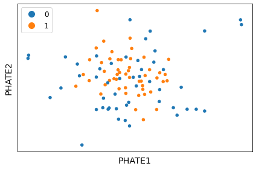

```python
phate.plot.scatter(data_phate[:,0],data_phate[:,1],c=clusters)
```

{% endraw %}

We'll double check this result with PCA

{% raw %}

```python
from sklearn.decomposition import PCA
pca = PCA(n_components=2)
pcs = pca.fit_transform(word2vec_embeddings)
```

{% endraw %} {% raw %}

```python
pcs
```

[output not shown]

[output cut: 45 more lines]

[output not shown]

{% endraw %} {% raw %}

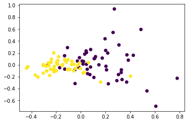

```python
plt.scatter(pcs[:,0],pcs[:,1],c=clusters)
```

{% endraw %}

# Does this work if it's undirected?

{% raw %}

```python
import networkx as nx
from torch_geometric.utils import to_networkx
G_nx = to_networkx(data, to_undirected=True)
```

{% endraw %} {% raw %}

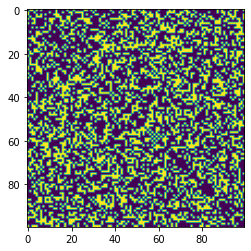

```python
A_s = 1/2*(A + A.T)
plt.imshow(A_s)
```

{% endraw %} {% raw %}

```python
from node2vec import Node2Vec
node2vec2 = Node2Vec(G_nx, dimensions=64, walk_length=30, num_walks=200, workers=4)  # Use temp_folder for big graphs
# Embed nodes
model2 = node2vec2.fit(window=10, min_count=1, batch_words=4)  # Any keywords acceptable by gensim.Word2Vec can be passed, `dimensions` and `workers` are automatically passed (from the Node2Vec constructor)

# Look for most similar nodes
model2.wv.most_similar('2')  # Output node names are always strings
```

```
[('35', 0.42945635318756104),
 ('4', 0.3440379500389099),
 ('21', 0.3429870307445526),
 ('1', 0.33976680040359497),
 ('19', 0.3339807689189911),
 ('44', 0.3329753875732422),
 ('6', 0.331703245639801),
 ('27', 0.3312684893608093),
 ('81', 0.32838162779808044),
 ('92', 0.3229937255382538)]
```

{% endraw %} {% raw %}

```python
word2vec_embeddings2 = model2.wv[wordlist]
```

{% endraw %} {% raw %}

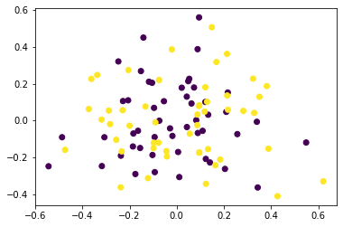

```python
from sklearn.decomposition import PCA
pca = PCA(n_components=2)
pcs = pca.fit_transform(word2vec_embeddings2)
plt.scatter(pcs[:,0],pcs[:,1],c=clusters)
```

{% endraw %}

# Bipartite Graph

{% raw %}

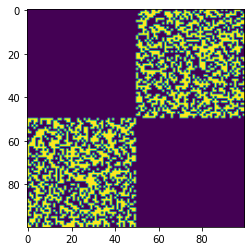

```python
from directed_graphs.datasets import DirectedStochasticBlockModel
aij = np.array([[0.0,1],[1,0]])
bij = np.array([[0.5,0.5],[0.5,0.5]])
dataset = DirectedStochasticBlockModel(num_nodes=100, num_clusters=2, aij = aij, bij = bij)
data = dataset[0] # there is only graph in this dataset
sparse_A = torch.sparse_coo_tensor(data.edge_index,torch.ones(data.edge_index.shape[1]))
A = sparse_A.to_dense()
plt.imshow(A)
```

{% endraw %} {% raw %}

```python
G_nx = to_networkx(data, to_undirected=False)
```

{% endraw %} {% raw %}

```python
from node2vec import Node2Vec
node2vec2 = Node2Vec(G_nx, dimensions=64, walk_length=30, num_walks=200, workers=4)  # Use temp_folder for big graphs
# Embed nodes
model2 = node2vec2.fit(window=10, min_count=1, batch_words=4)  # Any keywords acceptable by gensim.Word2Vec can be passed, `dimensions` and `workers` are automatically passed (from the Node2Vec constructor)

# Look for most similar nodes
model2.wv.most_similar('2')  # Output node names are always strings
```

```
[('38', 0.7977835536003113),
 ('23', 0.7971742749214172),
 ('42', 0.794073760509491),
 ('29', 0.7594153881072998),
 ('32', 0.7572621703147888),
 ('49', 0.7516230940818787),
 ('46', 0.7414773106575012),
 ('6', 0.7289462089538574),
 ('31', 0.7288908362388611),
 ('1', 0.717528760433197)]
```

{% endraw %} {% raw %}

```python
word2vec_embeddings2 = model2.wv[wordlist]
```

{% endraw %} {% raw %}

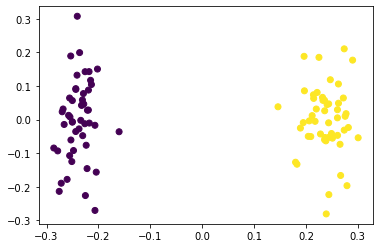

```python
from sklearn.decomposition import PCA
pca = PCA(n_components=2)
pcs = pca.fit_transform(word2vec_embeddings2)
plt.scatter(pcs[:,0],pcs[:,1],c=clusters)
```

{% endraw %}

Let's formalize the steps of running node2vec on a graph and obtaining a PCA plot.

{% raw %}

`node2vec_and_plot`[[source]](https://github.com/professorwug/directed_graphs/tree/master/directed_graphs/embeddings.py#L9)

> `node2vec_and_plot`(**`data`**, **`n_clusters`**, **`title`**=*`''`*)

{% endraw %} {% raw %}

{% endraw %}

# Sinks and Sources

{% raw %}

```
performing PCA...
```

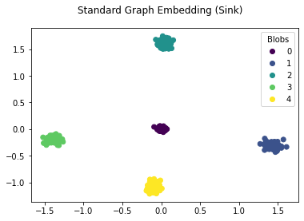

```python
from directed_graphs.datasets import sink_graph, source_graph
dataset = sink_graph(n_points = 500, num_clusters=5)
data = dataset[0]
ems = node2vec_and_plot(data,5,title="Standard Graph Embedding (Sink)")
```

{% endraw %} {% raw %}

```
performing PCA...
```

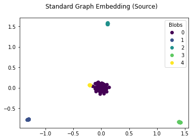

```python
dataset = source_graph(n_points = 500, num_clusters=5)
data = dataset[0]
ems = node2vec_and_plot(data,5, title="Standard Graph Embedding (Source)")
```

{% endraw %}

# Node2Vec on Simple Random Graphs

{% raw %}

```python
from directed_graphs.datasets import SmallRandom, visualize_graph, SourceSink
pre_transform = SourceSink(prob_source=0.5, prob_sink=0, adv_prob=0.1, remove_prob=0)
dataset = SmallRandom(num_nodes=20, prob_edge=0.2, pre_transform=pre_transform)
data = dataset[0] # there is only graph in this dataset
```

{% endraw %} {% raw %}

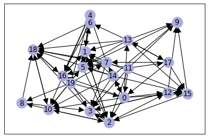

```python
visualize_graph(data)
```

{% endraw %} {% raw %}

```
performing PCA...
```

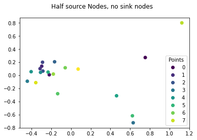

```python
G_nx = to_networkx(data, to_undirected=False)
n_points = data.x.shape[1]
node2vec2 = Node2Vec(G_nx, dimensions=64, walk_length=30, num_walks=200, workers=4)  # Use temp_folder for big graphs
# Embed nodes
model = node2vec2.fit(window=10, min_count=1, batch_words=4)  # Any keywords acceptable by gensim.Word2Vec can be passed, `dimensions` and `workers` are automatically passed (from the Node2Vec constructor)
# Get words
wordlist = [str(i) for i in range(n_points)]
# Extract embeddings
ems = model.wv[wordlist]
print("performing PCA...")
pca = PCA(n_components=2)
pcs = pca.fit_transform(ems)
plt.figure()
clusters = list(range(n_points))
# print(clusters)
scatter2 = plt.scatter(pcs[:,0],pcs[:,1],c=clusters)
plt.legend(handles = scatter2.legend_elements()[0], title="Points", labels=list(range(n_points)))
plt.suptitle("Half source Nodes, no sink nodes")
```

{% endraw %} {% raw %}

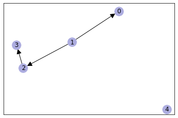

```python
from directed_graphs.datasets import SmallRandom, visualize_graph, SourceSink
pre_transform = SourceSink(prob_source=0, prob_sink=0, adv_prob=0.1, remove_prob=0)
dataset = SmallRandom(num_nodes=5, prob_edge=0.2, pre_transform=pre_transform)
data = dataset[0] # there is only graph in this dataset
visualize_graph(data)
```

{% endraw %} {% raw %}

```
performing PCA...
```

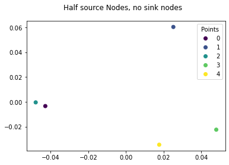

```python
G_nx = to_networkx(data, to_undirected=False)
n_points = data.x.shape[1]
node2vec2 = Node2Vec(G_nx, dimensions=64, walk_length=30, num_walks=200, workers=4)  # Use temp_folder for big graphs
# Embed nodes
model = node2vec2.fit(window=10, min_count=1, batch_words=4)  # Any keywords acceptable by gensim.Word2Vec can be passed, `dimensions` and `workers` are automatically passed (from the Node2Vec constructor)
# Get words
wordlist = [str(i) for i in range(n_points)]
# Extract embeddings
ems = model.wv[wordlist]
print("performing PCA...")
pca = PCA(n_components=2)
pcs = pca.fit_transform(ems)
plt.figure()
clusters = list(range(n_points))
scatter2 = plt.scatter(pcs[:,0],pcs[:,1],c=clusters)
plt.legend(handles = scatter2.legend_elements()[0], title="Points", labels=list(range(n_points)))
plt.suptitle("Half source Nodes, no sink nodes")
```

{% endraw %} {% raw %}

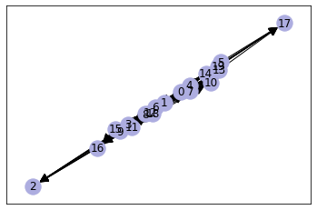

```python
from directed_graphs.datasets import SmallRandom, visualize_graph, SourceSink
pre_transform = SourceSink(prob_source=0, prob_sink=0.2, adv_prob=0.1, remove_prob=0)
dataset = SmallRandom(num_nodes=20, prob_edge=0.2, pre_transform=pre_transform)
data = dataset[0] # there is only graph in this dataset
visualize_graph(data)
```

{% endraw %} {% raw %}

```
performing PCA...
```

[figure not shown]

```python
G_nx = to_networkx(data, to_undirected=False)
n_points = data.x.shape[1]
node2vec2 = Node2Vec(G_nx, dimensions=64, walk_length=30, num_walks=200, workers=4)  # Use temp_folder for big graphs
# Embed nodes
model = node2vec2.fit(window=10, min_count=1, batch_words=4)  # Any keywords acceptable by gensim.Word2Vec can be passed, `dimensions` and `workers` are automatically passed (from the Node2Vec constructor)
# Get words
wordlist = [str(i) for i in range(n_points)]
# Extract embeddings
ems = model.wv[wordlist]
print("performing PCA...")
pca = PCA(n_components=2)
pcs = pca.fit_transform(ems)
plt.figure(figsize=(10,10))
clusters = list(range(n_points))
# scatter2 = plt.scatter(pcs[:,0],pcs[:,1],c=clusters)
# handles, _ = scatter2.legend_elements(prop='colors',num=25)
# plt.legend(handles = handles, title="Points", labels=list(range(n_points)))
# plt.suptitle("Half source Nodes, no sink nodes")
```

{% endraw %} {% raw %}

```
Calculating PHATE...
  Running PHATE on 20 observations and 64 variables.
  Calculating graph and diffusion operator...
    Calculating KNN search...
    Calculating affinities...
  Calculating optimal t...
    Automatically selected t = 24
  Calculating diffusion potential...
  Calculating metric MDS...
  Calculated metric MDS in 0.05 seconds.
Calculated PHATE in 0.06 seconds.
```

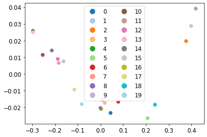

```python
import phate
import scprep
phate_op = phate.PHATE(knn=3,decay=30)
data_phate = phate_op.fit_transform(ems)
scprep.plot.scatter(data_phate[:,0],data_phate[:,1],c=list(range(n_points)))
```

{% endraw %}